# Practical_7

7.0 Exercise Start a new R notebook named practical_07.Rmd and save it to the rmd folder of your RStudio project practicals. Make sure that all the R packages you need are loaded at the beginning. All the following exercises should be attempted within R code chunks of this notebook.

```r
library(tidyverse)
library(ggrepel)
library(janitor)
library(lubridate)
library(gapminder)
```

# 7.1 Exercise

Consider again the gapminder data discussed in the lecture notes (recall that this data set is made available through library(“gapminder”)).

```r
gapminder
```

| country | continent | year | lifeExp | pop | gdpPercap |
| --- | --- | --- | --- | --- | --- |
| Afghanistan | Asia | 1952 | 28.80100 | 8425333 | 779.4453 |
| Afghanistan | Asia | 1957 | 30.33200 | 9240934 | 820.8530 |
| Afghanistan | Asia | 1962 | 31.99700 | 10267083 | 853.1007 |
| Afghanistan | Asia | 1967 | 34.02000 | 11537966 | 836.1971 |
| Afghanistan | Asia | 1972 | 36.08800 | 13079460 | 739.9811 |
| Afghanistan | Asia | 1977 | 38.43800 | 14880372 | 786.1134 |
| Afghanistan | Asia | 1982 | 39.85400 | 12881816 | 978.0114 |
| Afghanistan | Asia | 1987 | 40.82200 | 13867957 | 852.3959 |
| Afghanistan | Asia | 1992 | 41.67400 | 16317921 | 649.3414 |
| Afghanistan | Asia | 1997 | 41.76300 | 22227415 | 635.3414 |

[output cut: 990 more lines]

1. Create the following figures.
2. a histogram of life expectancies in different countries for the year 2007;

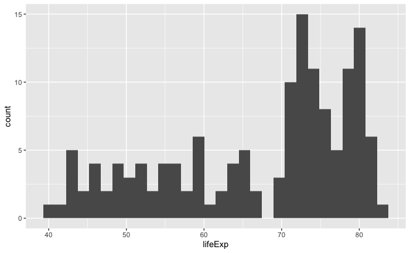

```r
gapminder_2007_plot <- gapminder %>%
  filter(year == 2007) %>%
  group_by(country) %>%
  ggplot(mapping = aes(x = lifeExp))

gapminder_2007_plot + geom_histogram()
```

[figure not shown]

```r
gapminder_2007_plot
```

a boxplot of life expectancies in different countries for the year 2007;

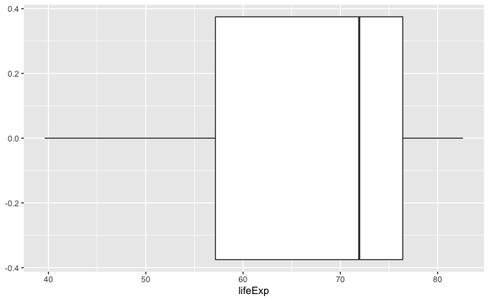

```r
gapminder_2007_plot + geom_boxplot()
```

```r
# I think I need the other grouping function
```

3. a line graph showing how life expectancy has evolved in the United Kingdom;

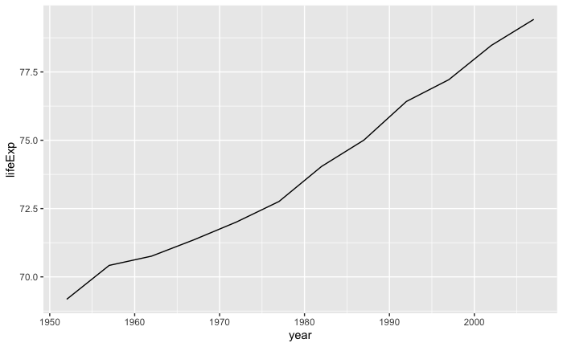

```r
gapminder %>%
  filter(country == "United Kingdom") %>%
  ggplot() +
  geom_line(mapping = aes(y = lifeExp, x = year))
```

4. a scatterplot of GDP per capita vs life expectancy.

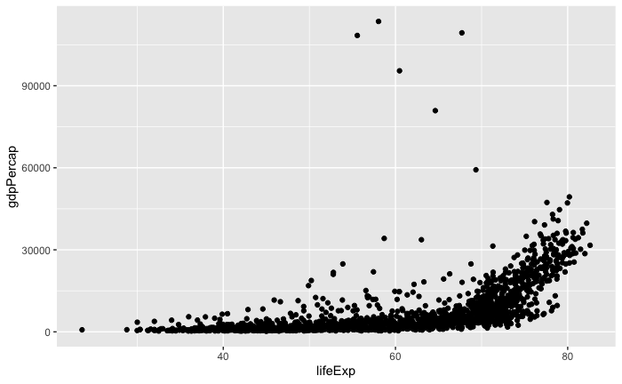

```r
gapminder %>%
  ggplot() +
  geom_point(mapping = aes(x = lifeExp, y = gdpPercap))
```

2. Recreate the following figure which shows the GDP per capita for countries in Asia in 2007.

```r
gapminder_asia_plot <- gapminder %>%
  filter(continent == "Asia" & year == "2007") %>%
  ggplot() +
  geom_col(mapping = aes(x = gdpPercap, y = country))
```

3. Unless your data have a natural order (as, e.g., in time-series data), it is often sensible to order your data. With this in mind, improve the following figure. Hint: you may find the base R function reorder() useful which takes two arguments and which thus allows you to reorder the entries in x according to the elements in y by typing reorder(x, y).

[figure not shown]

```r
gapminder_asia_plot+
  geom_col(mapping = aes(y = reorder(country, gdpPercap), x = gdpPercap, fill = lifeExp))
```

4. Visualise, using a single line, how the global average life expectancy has evolved between 1952 and 2007. Make sure to take the different population sizes in different countries into account. You may find the function weighted.mean() helpful.

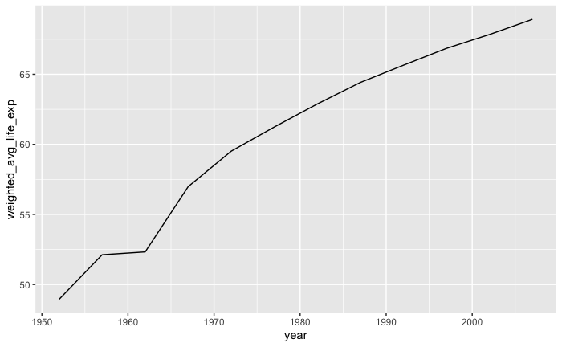

```r
global_life_exp <- gapminder %>%
  filter(between(year,1952, 2007)) %>%
  group_by(year) %>%
  summarise(weighted_avg_life_exp = weighted.mean(lifeExp, w = pop))
# assuming w stands for weighting

(global_life_exp_plot <- global_life_exp %>%
  ggplot() +
  geom_line(mapping = aes(x = year, y = weighted_avg_life_exp)))
```

5. Visualise how the life expectancy in your own country has evolved relative to the weighted average of other, similar countries, e.g. its neighbours (with weighting by population size).

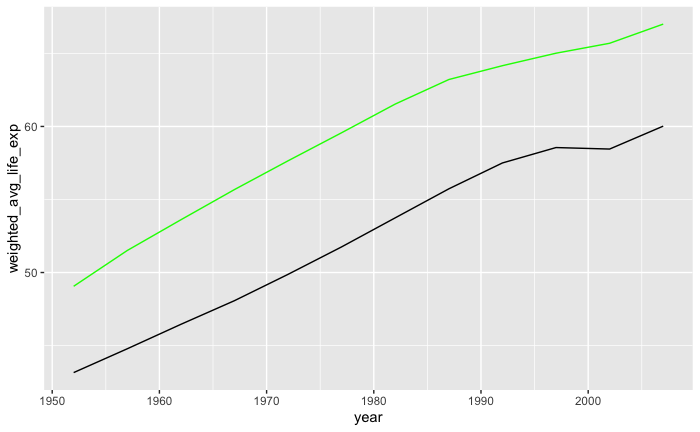

```r
global_life_exp <- gapminder %>%
  filter(between(year,1952, 2007)) %>%
  group_by(year) %>%
  summarise(weighted_avg_life_exp = weighted.mean(lifeExp))

ghana_life_exp <- gapminder %>%
  filter(between(year,1952, 2007),
         country == "Ghana"
  ) %>%
  group_by(year) %>%
  summarise(ghana_avg = weighted.mean(lifeExp))

relative_gh <- left_join(global_life_exp, ghana_life_exp, by = "year")

relative_gh %>%
  ggplot() +
  geom_line(mapping = aes(x = year, y = weighted_avg_life_exp), colour = "green") +
  geom_line(mapping = aes(x = year, y = ghana_avg))
```

6. Visualise the how the life expectancy has evolved between 1952 and 2007 for all countries in the data set without differentiating them visually (i.e. draw one black line for each country).

```r
 # have to use the group thing

global_life_exp_2 <- gapminder %>%
  filter(between(year,1952, 2007)) %>%
  group_by(year, country) %>%
  summarise(weighted_avg_life_exp = weighted.mean(lifeExp))
global_life_exp_2
```

| year | country | weighted_avg_life_exp |
| --- | --- | --- |
| 1952 | Afghanistan | 28.80100 |
| 1952 | Albania | 55.23000 |
| 1952 | Algeria | 43.07700 |
| 1952 | Angola | 30.01500 |
| 1952 | Argentina | 62.48500 |
| 1952 | Australia | 69.12000 |
| 1952 | Austria | 66.80000 |
| 1952 | Bahrain | 50.93900 |
| 1952 | Bangladesh | 37.48400 |
| 1952 | Belgium | 68.00000 |

[output cut: 990 more lines]

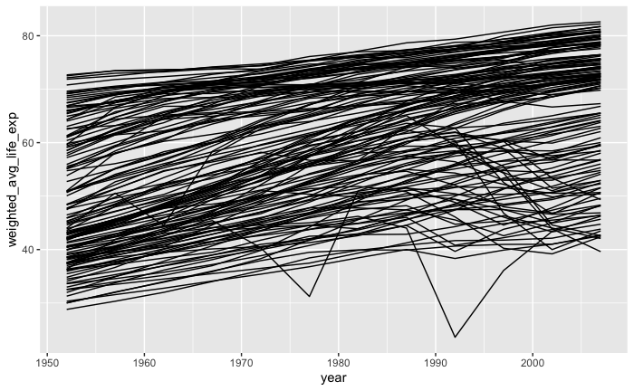

```r
global_life_exp_plot <- global_life_exp_2 %>%
  ggplot() +
  geom_line(mapping = aes(x = year, y = weighted_avg_life_exp, group = country))

global_life_exp_plot
```

```r
# damn
```

7. Create the same graph as before but now ensure that the lines have different colours depending on the continent to which a country belongs. Also plot the same figure but with different line types instead of colours for each continent.

```r
# different colours

global_life_exp_3 <- gapminder %>%
  filter(between(year,1952, 2007)) %>%
  group_by(year, country, continent) %>%
  summarise(weighted_avg_life_exp = weighted.mean(lifeExp))
global_life_exp_3
```

| year | country | continent | weighted_avg_life_exp |
| --- | --- | --- | --- |
| 1952 | Afghanistan | Asia | 28.80100 |
| 1952 | Albania | Europe | 55.23000 |
| 1952 | Algeria | Africa | 43.07700 |
| 1952 | Angola | Africa | 30.01500 |
| 1952 | Argentina | Americas | 62.48500 |
| 1952 | Australia | Oceania | 69.12000 |
| 1952 | Austria | Europe | 66.80000 |
| 1952 | Bahrain | Asia | 50.93900 |
| 1952 | Bangladesh | Asia | 37.48400 |
| 1952 | Belgium | Europe | 68.00000 |

[output cut: 990 more lines]

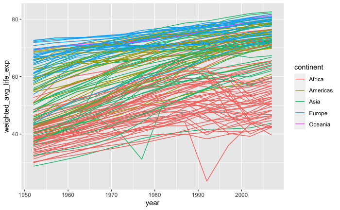

```r
global_life_exp_plot <- global_life_exp_3 %>%
  ggplot() +
  geom_line(mapping = aes(x = year, y = weighted_avg_life_exp, colour = continent, group = country))

global_life_exp_plot
```

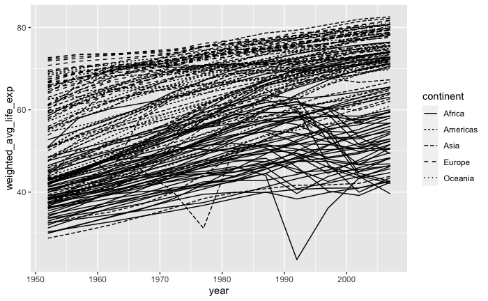

```r
# different linetype

global_life_exp_plot_2 <- global_life_exp_3 %>%
  ggplot() +
  geom_line(mapping = aes(x = year, y = weighted_avg_life_exp, linetype = continent, group = country))

global_life_exp_plot_2
```

8. Visualise how the continent-wise average life expectancy has evolved between 1952 and 2007 via a suitable graph.

```r
gapminder_continent <- gapminder %>%
  filter(between(year, 1952, 2007)) %>%
  group_by(year, continent) %>%
  select(continent, year, lifeExp) %>%
  mutate(avg_life_exp = mean(lifeExp))

gapminder_continent
```

| continent | year | lifeExp | avg_life_exp |
| --- | --- | --- | --- |
| Asia | 1952 | 28.80100 | 46.31439 |
| Asia | 1957 | 30.33200 | 49.31854 |
| Asia | 1962 | 31.99700 | 51.56322 |
| Asia | 1967 | 34.02000 | 54.66364 |
| Asia | 1972 | 36.08800 | 57.31927 |
| Asia | 1977 | 38.43800 | 59.61056 |
| Asia | 1982 | 39.85400 | 62.61794 |
| Asia | 1987 | 40.82200 | 64.85118 |
| Asia | 1992 | 41.67400 | 66.53721 |
| Asia | 1997 | 41.76300 | 68.02052 |

[output cut: 990 more lines]

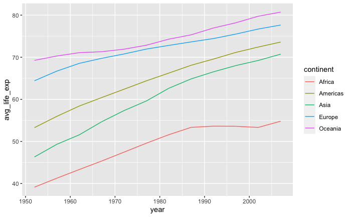

```r
gapminder_continent %>%
  ggplot() +
  geom_line(mapping = aes(x = year, y = avg_life_exp, group = continent, colour = continent))
```

1. Create a scatterplot of the base-10 logarithm of GDP per capita vs life expectancy in 2007 such that the colour of the points differs with continent and the size of the points gives information about the population size.

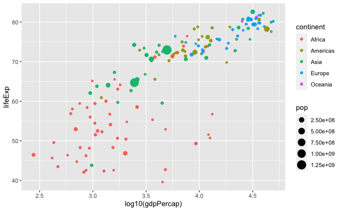

```r
gapminder_2007 <- gapminder %>%
  filter(year == 2007)

gapminder_2007 %>%
  ggplot() +
  geom_point(mapping = aes(x = log10(gdpPercap), y = lifeExp, colour = continent, size = pop))
```

10. Plot a scatterplot of the base-10 logarithm of GDP per capita vs life expectancy such that the colour of the points is differs with the year, i.e. colour = year. What happens if you map colour = as.factor(year) or colour = as.ordered(year)instead. Which do you find more sensible?

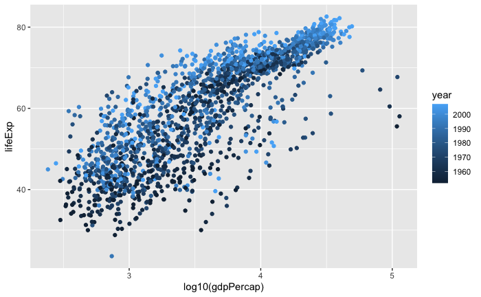

```r
   p <- ggplot(
           data    = gapminder,
           mapping = aes(x = log10(gdpPercap), y = lifeExp)
         )

    # continuous colour scale doesn't seem appropriate because
    # we only have round years in our data set.
    p + geom_point(mapping = aes(colour = year))
```

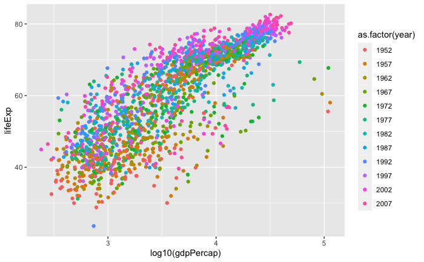

```r
    # qualitative colour scheme doesn't seem appropriate either because we lose
    # all the information about the ordering (in time).
    p + geom_point(mapping = aes(colour = as.factor(year)))
```

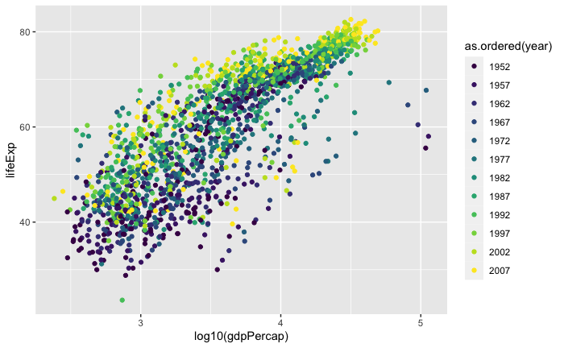

```r
    # sequential but discrete colour scheme seems more appropriate.
    p + geom_point(mapping = aes(colour = as.ordered(year)))
```

11. Explain what is wrong with the following (without running the code).

```r
ggplot(data = gapminder) +
  geom_point(mapping = aes(x = log10(gdpPercap), y = lifeExp, shape = pop))
```

```
Error: A continuous variable can not be mapped to shape
Run `rlang::last_error()` to see where the error occurred.
```

We are trying to map a continuous variable to a shape which is not possible as shapes only work with discrete variables.

12. ggplot(data = gapminder) + geom_point(mapping = aes(x = log10(gdpPercap), y = lifeExp, shape = pop)) Reproduce the following figures in which pop_in_bn is the total global population [in billion persons] and gdp_in_tn is the total global GDP [in trillion US dollars].

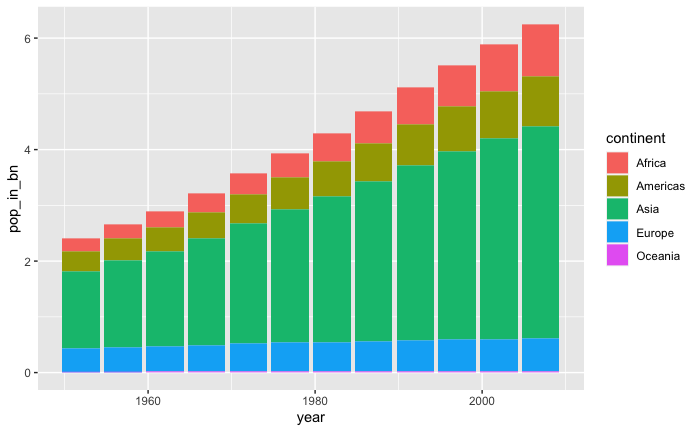

```r
gapminder %>%
  group_by(year, continent) %>%
  summarise(pop_in_bn = sum(pop) / 10^9) %>%
  ggplot(mapping = aes(x = year, y = pop_in_bn, fill = continent)) +
  geom_col()
```

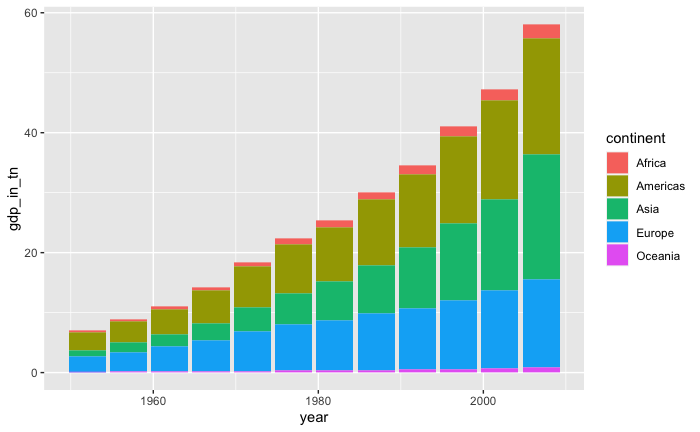

```r
    gapminder %>%
      group_by(year, continent) %>%
      summarise(gdp_in_tn = sum(pop * gdpPercap) / 10^12) %>%
      ggplot(mapping = aes(x = year, y = gdp_in_tn, fill = continent)) +
      geom_col()
```

13. Modify the figures from the previous question in such a way that they better emphasise the proportion of the total global population or total global GDP that different continents account for.

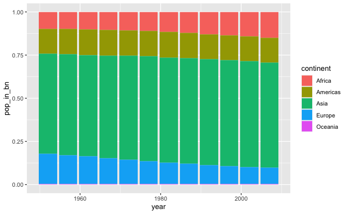

```r
  gapminder %>%
      group_by(year, continent) %>%
      summarise(pop_in_bn = sum(pop) / 10^9) %>%
      ggplot(mapping  = aes(x = year, y = pop_in_bn, fill = continent)) +
      geom_col(position = position_fill())
```

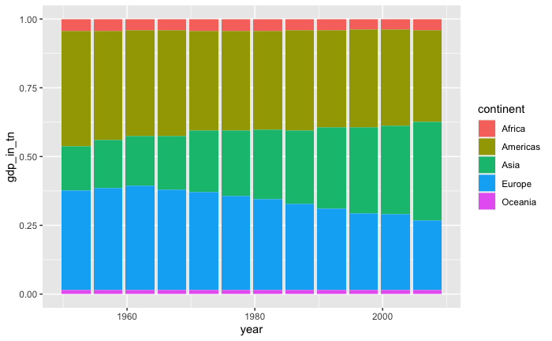

```r
    gapminder %>%
      group_by(year, continent) %>%
      summarise(gdp_in_tn = sum(pop * gdpPercap) / 10^12) %>%
      ggplot(mapping = aes(x = year, y = gdp_in_tn, fill = continent)) +
      geom_col(position = position_fill())
```

```r
NA
```

14. Which position adjustment would you need to have the bars for each continent side-by-side rather than stacked on top of one another?

position_dodge

# Exercise 7.2

7.2 Exercise According to the “Data visualisation with ggplot2” cheat sheet, both geom_col() and geom_bar() create bar plots.

1. Why does geom_col() require both the x and y aesthetic whereas geom_bar() only requires the x aesthetic?

geom_bar() only requires the x-aesthetic because it automatically counts the number of cars in each class and then plots the heights of the bars accordingly.

2. Recreate the following figure using geom_col() and geom_bar().

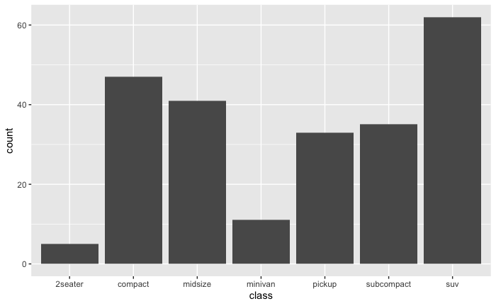

```r
# geom col
mpg %>%
  count(class, name = "count") %>%
  ggplot()+
  geom_col(mapping = aes(x = class, y = count))
```

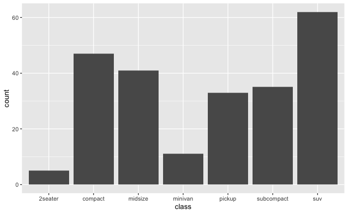

```r
# you need to create a count for class before you can use it keep this in mind for next time

# geom bar
mpg %>%
  ggplot() +
  geom_bar(mapping = aes(x = class))
```